# Building a recommender system Part III - pre-processing

## Building a recommender system from scratch

### Step 3 Pre-processing

What if we built a movie recommender? In order to do this we would have to gather 4 things.

1. Movies classified by their levels of Action, Comedy, Drama, etc ranging from 0 to 10 for example link to the article
2. A database of people together with their movie reviews ie. likes, comments, shares link to the article
3. Pre-process the data so that it can be fed into existing sci-kit learn libraries current article
4. Last but not least we need a good grasp of the statistical (or deep learning) concepts we want to apply [Christopher Fonnesbeck's video](https://www.youtube.com/watch?v=TMmSESkhRtI&t=5290s) is a good introduction to statistical modeling with Python if you're just starting out

The target value we are trying to predict is the movie we would recommend based on movie preferences. Movie preference can be infered through movie reviews in step 2.

Credits: this notebook is highly inspired by [Frank Kane's course material on Udemy](https://www.udemy.com/data-science-and-machine-learning-with-python-hands-on/)

Let's get our output file from the previous section and map user reviews and movie data

### Reading the data in

```python
import pandas as pd
import os
import seaborn as sns
import numpy as np

%matplotlib inline

pd.set_option('display.width', 500)
pd.set_option('display.max_columns', 100)
pd.set_option('display.notebook_repr_html', True)

def search_import_file(a,b):
    liste=[]
    for i in os.listdir(os.path.curdir):
        liste.append(i)
    for file in liste:
        if (file.startswith(a) and file.endswith(b)):
            curdir = os.path.abspath(os.path.curdir)
            path_to_file = os.path.join(curdir,file)
            # print("found",path_to_file)
    return path_to_file

input_file = search_import_file('Imdb','xlsx')

df_movies = pd.read_excel(input_file, sheetname='Imdb')
df_users = pd.read_excel(input_file, sheetname='User_reviews')

print("df_movies has",df_movies.shape[0],"unique movies")
print("df_users has",df_users.shape[0],"unique user reviews")
```

```
df_movies has 509 unique movies
df_users has 5888 unique user reviews
```

### Data manipulation

We'll add an index and shorten the references into id's

```python
df_users.head(2)
```

|  | id | index | Rating | Title |
| --- | --- | --- | --- | --- |
| 0 | tt0012349 | /user/ur0453068/?ref_=tt_urv | 10 | O Garoto de Charlot (1921) |
| 1 | tt0012349 | /user/ur0562732/?ref_=tt_urv | 10 | O Garoto de Charlot (1921) |

```python
df_users = df_users.reset_index()

def get_id(row):
    return(row[6:16])

df_users['user_id'] = df_users.apply(lambda row: get_id(row['index']), axis=1)
df_users.set_index('id', inplace = True)
df_users.drop(['index', 'level_0'], axis = 1, inplace=True)
df_users.index[df_users.index.str.endswith('/')]
# returns an empty array so this means we extracted all integers from the movie id as expected
```

```
Index([], dtype='object', name='id')
```

```python
df_users.head(2)
```

| id | Rating | Title | user_id |
| --- | --- | --- | --- |
| tt0012349 | 10 | O Garoto de Charlot (1921) | ur0453068/ |
| tt0012349 | 10 | O Garoto de Charlot (1921) | ur0562732/ |

```python
df_movies.head(2)
```

|  | Link | Action | Adventure | Animation | Biography | Comedy | Crime | Drama | Family | Fantasy | History | Horror | Music | Mystery | Romance | Sci_Fi | Thriller | Title | War | Western |
| --- | --- | --- | --- | --- | --- | --- | --- | --- | --- | --- | --- | --- | --- | --- | --- | --- | --- | --- | --- | --- |
| 0 | /title/tt3606756/?pf_rd_m=A2FGELUUNOQJNL&pf_rd... | 1 | 1 | 1 | 0 | 0 | 0 | 0 | 0 | 0 | 0 | 0 | 0 | 0 | 0 | 0 | 0 | The Incredibles 2: Os Super-Heróis (2018) | 0 | 0 |
| 1 | /title/tt4881806/?pf_rd_m=A2FGELUUNOQJNL&pf_rd... | 1 | 1 | 0 | 0 | 0 | 0 | 0 | 0 | 0 | 0 | 0 | 0 | 0 | 0 | 1 | 0 | Mundo Jurássico: Reino Caído (2018) | 0 | 0 |

```python
def get_id(row):
    return(row[7:16])

df_movies['id'] = df_movies.apply(lambda row: get_id(row['Link']), axis=1)

df_movies.set_index('id', inplace = True)
df_movies.drop(['Link','Title'], axis = 1, inplace=True)
df_movies.index[df_movies.index.str.endswith('/')]
# returns an empty array so this means we extracted all integers from the movie id as expected
```

```
Index([], dtype='object', name='id')
```

```python
df_movies.head(2)
```

| id | Action | Adventure | Animation | Biography | Comedy | Crime | Drama | Family | Fantasy | History | Horror | Music | Mystery | Romance | Sci_Fi | Thriller | War | Western |
| --- | --- | --- | --- | --- | --- | --- | --- | --- | --- | --- | --- | --- | --- | --- | --- | --- | --- | --- |
| tt3606756 | 1 | 1 | 1 | 0 | 0 | 0 | 0 | 0 | 0 | 0 | 0 | 0 | 0 | 0 | 0 | 0 | 0 | 0 |
| tt4881806 | 1 | 1 | 0 | 0 | 0 | 0 | 0 | 0 | 0 | 0 | 0 | 0 | 0 | 0 | 1 | 0 | 0 | 0 |

```python
merge = df_users.join(df_movies)
merge.head(2)
```

[output not shown]

### Data exploration

Let's build some arrays to support our data visualisations

```python
genres = ['Action','Adventure','Animation','Biography','Comedy','Crime','Drama','Family','Fantasy','History',
          'Horror','Music','Mystery','Romance','Sci_Fi','Thriller','War','Western']

# np arrays we'll use later on to filter
Action = merge['Action'][merge['Action'] > 0].index.unique().values
Adventure = merge['Adventure'][merge['Adventure'] > 0].index.unique().values
Animation = merge['Animation'][merge['Animation'] > 0].index.unique().values
Biography = merge['Biography'][merge['Biography'] > 0].index.unique().values
Comedy = merge['Comedy'][merge['Comedy'] > 0].index.unique().values
Crime = merge['Crime'][merge['Crime'] > 0].index.unique().values
Drama = merge['Drama'][merge['Drama'] > 0].index.unique().values
Family = merge['Family'][merge['Family'] > 0].index.unique().values
Fantasy = merge['Fantasy'][merge['Fantasy'] > 0].index.unique().values
History = merge['History'][merge['History'] > 0].index.unique().values
Horror = merge['Horror'][merge['Horror'] > 0].index.unique().values
Music = merge['Music'][merge['Music'] > 0].index.unique().values
Mystery = merge['Mystery'][merge['Mystery'] > 0].index.unique().values
Romance = merge['Romance'][merge['Romance'] > 0].index.unique().values
Sci_Fi = merge['Sci_Fi'][merge['Sci_Fi'] > 0].index.unique().values
Thriller = merge['Thriller'][merge['Thriller'] > 0].index.unique().values
War = merge['War'][merge['War'] > 0].index.unique().values
Western = merge['Western'][merge['Western'] > 0].index.unique().values

# create a list with the numpy arrays we just created
genres_np = [Action,Adventure,Animation,Biography,Comedy,Crime,Drama,Family,Fantasy,History,
             Horror,Music,Mystery,Romance,Sci_Fi,Thriller,War,Western]
```

```python
Action #numpy.ndarray of action movies
```

```
array(['tt0015324', 'tt0017925', 'tt0055630', 'tt0076759', 'tt0080684',
       'tt0082971', 'tt0086190', 'tt0089881', 'tt0090605', 'tt0092099',
       'tt0095016', 'tt0097576', 'tt0103064', 'tt0119567', 'tt0133093',
       'tt0172495', 'tt0266697', 'tt0317705', 'tt0364569', 'tt0369610',
       'tt0372784', 'tt0434409', 'tt0451279', 'tt0458339', 'tt0468569',
       'tt0892769', 'tt0974015', 'tt1137450', 'tt1259528', 'tt1345836',
       'tt1365519', 'tt1375666', 'tt1392190', 'tt1431045', 'tt1469304',
       'tt1677720', 'tt1825683', 'tt2015381', 'tt2226597', 'tt2231461',
       'tt2250912', 'tt2283362', 'tt2527336', 'tt2557478', 'tt2704998',
       'tt3315342', 'tt3371366', 'tt3397884', 'tt3501632', 'tt3532216',
       'tt3606756', 'tt3778644', 'tt3896198', 'tt4154756', 'tt4881806',
       'tt5013056', 'tt5052474', 'tt5074352', 'tt5095030', 'tt5164214',
       'tt5463162', 'tt5834262', 'tt6306064', 'tt6499752', 'tt6513656',
       'tt7431594', 'tt7690670'], dtype=object)
```

```python
df_users.loc[Action,'Rating'].describe()
```

```
count    1532.000000
mean        6.300261
std         3.624422
min         1.000000
25%         2.000000
50%         8.000000
75%        10.000000
max        10.000000
Name: Rating, dtype: float64
```

```python
df_users['Rating'].describe()
```

```
count    5888.000000
mean        7.259681
std         3.391101
min         1.000000
25%         5.000000
50%         9.000000
75%        10.000000
max        10.000000
Name: Rating, dtype: float64
```

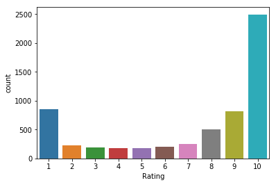

```python
sns.countplot('Rating',data=df_users)
```

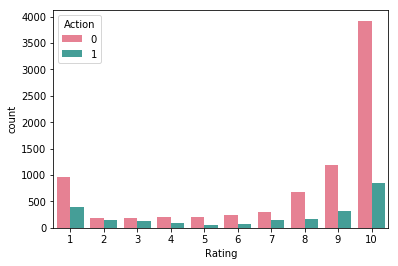

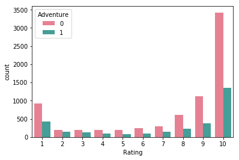

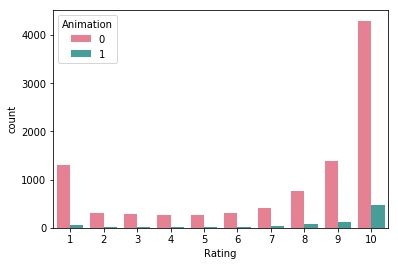

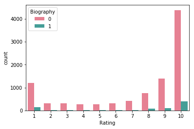

```python
import matplotlib.pyplot as plt

for genre in genres:
    sns.countplot('Rating',hue=genre, data=merge, palette='husl')
    plt.figure()
```

```python
df_movies.sum().sort_values(ascending=False)
```

```
Drama        315
Adventure    149
Action       116
Crime         99
Comedy        96
Thriller      75
Sci_Fi        63
Mystery       56
Fantasy       49
Animation     43
Biography     41
Romance       36
War           31
Family        24
History       23
Horror        21
Music         14
Western       12
dtype: int64
```

```python
total = df_movies.sum().sum()
```

```python
interest = df_movies.sum()['Drama']+df_movies.sum()['Action']+df_movies.sum()['Adventure']
```

```python
interest/total
```

```
0.4592240696753761
```

```python
#df_users['Rating'].mean()
d = []
for i, genre in enumerate(genres_np):
    #print(genre)
    mean = df_users.loc[genre,'Rating'].mean()
    mode = df_users.loc[genre,'Rating'].mode()[0]
    #print("{} has a mean Rating of {:.1f} and a mode of {}".format(genres[i],mean,mode))
    d.append({'Genre':genres[i],'Mean':mean,'Mode':mode})
data = pd.DataFrame(d)

data = data.sort_values(by="Mean",ascending=False)
data.set_index('Genre', inplace = True)
data
```

| Genre | Mean | Mode |
| --- | --- | --- |
| Family | 8.369231 | 10 |
| Animation | 8.253898 | 10 |
| Romance | 8.164114 | 10 |
| Western | 8.136000 | 10 |
| Drama | 7.664062 | 10 |
| Mystery | 7.545000 | 10 |
| Biography | 7.470982 | 10 |
| War | 7.432515 | 10 |
| Comedy | 7.229976 | 10 |
| Crime | 7.200000 | 10 |
| History | 7.159533 | 10 |
| Music | 7.022059 | 10 |
| Thriller | 6.918072 | 10 |
| Adventure | 6.825315 | 10 |
| Sci_Fi | 6.750322 | 10 |
| Fantasy | 6.693380 | 10 |
| Action | 6.300261 | 10 |
| Horror | 5.900398 | 10 |

### Finding similar movies to Indiana Jones

Let's lay the groundwork for our recommender by first getting a sense of how to find similar movies to a single movie first. But before jumping into the data let's get some intuition with an example first

```python
movie_reviews = (pd.DataFrame(data={"Indiana Jones":[10,9,8,3,3],"Star Wars":[9,8,8,1,5],
                                    "Inception":[10,10,10,1,5],"Pokemon":[5,1,1,6,5]},
                              index=['User1', 'User2','User3','User4','User5']))
movie_reviews = movie_reviews.astype(float)
movie_reviews
```

|  | Inception | Indiana Jones | Pokemon | Star Wars |
| --- | --- | --- | --- | --- |
| User1 | 10.0 | 10.0 | 5.0 | 9.0 |
| User2 | 10.0 | 9.0 | 1.0 | 8.0 |
| User3 | 10.0 | 8.0 | 1.0 | 8.0 |
| User4 | 1.0 | 3.0 | 6.0 | 1.0 |
| User5 | 5.0 | 3.0 | 5.0 | 5.0 |

```python
movie_reviews.corrwith(movie_reviews["Indiana Jones"]).drop("Indiana Jones")
```

```
Inception    0.917219
Pokemon     -0.580557
Star Wars    0.895788
dtype: float64
```

Based on these fake user reviews you can see how we will go about building our recommender. We look at the ratings given to Indiana Jones and compute the correlation with the other movies in the set. Indiana Jones is very similar to Star wars and inception because users rated them very similarly ie. these movie vectors are highly correlated cor ≈ 1

Similarity is given by the corrwith function which is the covariance of both distributions divided by the standard deviation of both distributions

cor(X, Y) = Cov(X, Y)/sd(X)*sd(Y)

The standard deviation is a measure of variance in the distribution ie. the sum of the distances between the samples and the mean.

[figure not shown]

The covariance on the other hand gives us the amount of variation between X and Y as well as the relationship between the distributions ie. whether there is a positive relationship or a negative one.

```python
df_users.groupby('Title').mean().sort_values(by='Rating',ascending=False).head()
```

| Title | Rating |
| --- | --- |
| Homem-Aranha: Regresso a Casa (2017) | 9.960000 |
| Toy Story 3 (2010) | 9.916667 |
| Casablanca (1942) | 9.894737 |
| O Túmulo dos Pirilampos (1988) | 9.863636 |
| O Senhor dos Anéis - A Irmandade do Anel (2001) | 9.857143 |

The highest rated movie in our set is Spiderman. Let's see if this ranking is similar when we account for the number of reviews for each movie

```python
sorted_by_size = (df_users.groupby('id').agg({'Rating':[np.size, np.mean]})
                 .sort_values(by=[('Rating','size'),('Rating','mean')],ascending=False))
(df_users.groupby('Title').agg({'Rating':[np.size, np.mean]})
                 .sort_values(by=[('Rating','size'),('Rating','mean')],ascending=False)).head()
```

| Title | Rating size | Rating mean |
| --- | --- | --- |
| Homem-Aranha: Regresso a Casa (2017) | 25 | 9.96 |
| Exterminador Implacável 2: O Dia do Julgamento (1991) | 25 | 9.76 |
| Léon, o Profissional (1994) | 25 | 9.68 |
| Jumanji: Bem-Vindos à Selva (2017) | 25 | 9.24 |
| Book Club (2018) | 25 | 8.72 |

```python
df_users['Title'][df_users['Title']=="Os Salteadores da Arca Perdida (1981) "].head(1)
```

```
id
tt0082971    Os Salteadores da Arca Perdida (1981)
Name: Title, dtype: object
```

There seems to be a problem with pandas when filtering based on this non-formatted columns due to the improper storing of the data on our previous stage. Let's circumvent this problem by referencing the movie id we created ealier.

```python
len(df_users.loc['tt0082971',:])
```

```
22
```

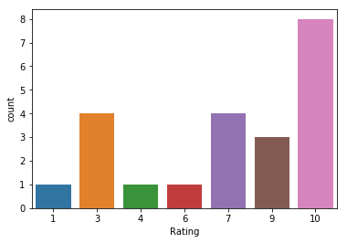

```python
rated_indiana_jones = df_users.loc['tt0082971',:]
rated_indiana_jones.set_index('user_id', inplace = True)
rated_indiana_jones = rated_indiana_jones.drop(["Title"], axis = 1)

sns.countplot('Rating',data=rated_indiana_jones)
```

```python
#pd.crosstab(liked_indiana_jones)
#liked_indiana_jones#.groupby("Rating").sum()
rated_indiana_jones['Rating'].value_counts()
```

```
10    8
7     4
3     4
9     3
6     1
4     1
1     1
Name: Rating, dtype: int64
```

```python
liked_indiana_jones = rated_indiana_jones[rated_indiana_jones>7]#.dropna().groupby("user_id").count().index.values
liked_indiana_jones.dropna()
```

| user_id | Rating |
| --- | --- |
| ur0024463/ | 10.0 |
| ur0102816/ | 9.0 |
| ur0176092/ | 9.0 |
| ur0270791/ | 10.0 |
| ur0355122/ | 10.0 |
| ur1111192/ | 10.0 |
| ur15140057 | 10.0 |
| ur2939100/ | 10.0 |
| ur3481942/ | 10.0 |
| ur4283909/ | 9.0 |
| ur4961908/ | 10.0 |

```python
movieRatings = df_users.pivot_table(index=['user_id'],columns=['id'],values='Rating', dropna=True)
movieRatings.head()
```

| id user_id | tt0012349 | tt0015324 | tt0015864 | tt0017136 | tt0017925 | tt0018455 | tt0019254 | tt0021749 | tt0022100 | tt0027977 | tt0031381 | tt0031679 | tt0032553 | tt0033467 | tt0034583 | tt0036775 | tt0038650 | tt0040522 | tt0040897 | tt0041959 | tt0042192 | tt0042876 | tt0043014 | tt0044741 | tt0045152 | tt0046268 | tt0046438 | tt0046912 | tt0047296 | … |
| --- | --- | --- | --- | --- | --- | --- | --- | --- | --- | --- | --- | --- | --- | --- | --- | --- | --- | --- | --- | --- | --- | --- | --- | --- | --- | --- | --- | --- | --- | --- |
| ur0001785/ | NaN | 10.0 | NaN | NaN | NaN | NaN | NaN | NaN | NaN | NaN | NaN | NaN | NaN | NaN | NaN | NaN | NaN | NaN | NaN | NaN | NaN | NaN | NaN | NaN | NaN | NaN | NaN | NaN | NaN | … |
| ur0003136/ | NaN | NaN | NaN | NaN | NaN | NaN | NaN | NaN | NaN | NaN | NaN | NaN | NaN | NaN | NaN | NaN | NaN | NaN | NaN | NaN | NaN | NaN | NaN | NaN | NaN | NaN | NaN | NaN | NaN | … |
| ur0004593/ | NaN | NaN | NaN | NaN | NaN | NaN | NaN | NaN | NaN | NaN | NaN | NaN | NaN | NaN | NaN | NaN | NaN | NaN | NaN | NaN | NaN | NaN | NaN | NaN | NaN | NaN | NaN | NaN | NaN | … |
| ur0005435/ | NaN | NaN | NaN | NaN | NaN | NaN | NaN | NaN | NaN | NaN | NaN | NaN | NaN | NaN | NaN | NaN | NaN | NaN | NaN | NaN | NaN | NaN | NaN | NaN | NaN | NaN | NaN | NaN | NaN | … |
| ur0008873/ | NaN | NaN | NaN | NaN | NaN | NaN | NaN | NaN | NaN | NaN | NaN | NaN | NaN | NaN | NaN | NaN | NaN | NaN | NaN | NaN | NaN | NaN | NaN | NaN | NaN | NaN | NaN | NaN | NaN | … |

5 rows × 272 columns

```python
#df_users_test = df_users.reset_index()
#movieRatings = df_users.pivot_table(index=['user_id'],columns=['id'],values='Rating')
corr = movieRatings.corrwith(liked_indiana_jones.iloc[:,0].astype(float))#.sort_values(ascending=False)

result = corr.to_frame().join(sorted_by_size, how='inner') # add (Rating, size) and (Rating, mean) columns
result = result.join(merge['Title'], how='inner') # add Title column
result = result.drop_duplicates().dropna().sort_values(by=[('Rating','size')],ascending=False)
result[result.loc[:,0] > 0]
```

| id | 0 | (Rating, size) | (Rating, mean) | Title |
| --- | --- | --- | --- | --- |
| tt0103064 | 1.0 | 25 | 9.760000 | Exterminador Implacável 2: O Dia do Julgamento... |
| tt0082971 | 1.0 | 22 | 7.181818 | Os Salteadores da Arca Perdida (1981) |
| tt0059578 | 1.0 | 21 | 9.047619 | Por Mais Alguns Dólares (1965) |
| tt0113277 | 1.0 | 21 | 8.333333 | Heat - Cidade Sob Pressão (1995) |
| tt0060196 | 1.0 | 20 | 9.800000 | O Bom, o Mau e o Vilão (1966) |
| tt0076759 | 1.0 | 20 | 9.150000 | Star Wars: Episódio IV - Uma Nova Esperança (1... |
| tt0093058 | 1.0 | 19 | 8.947368 | Nascido Para Matar (1987) |

There we have it, Indiana Jones is similar to itself, Terminator 2, For A Few Dollars More, Heat, the good, the bad and the ugly, born to kill and star wars. This similarity score is given by corrwith which computes the correlation of the Indiana Jones column with every other movie vector

### Recommending similar movies to a user

Now that we have formulated the premises of our recommender system let's generalize the algorythm. Instead of recommending based on a specific movie let's recommend based on the preferences of a given user ie look at similarities with a collection of movies instead of one movie as we suppose we are recommending to users who have reviewed more than one movie

```python
movieRatings = movieRatings.corr(method='pearson',min_periods=4)
movieRatings.head()
```

| id | tt0012349 | tt0015324 | tt0015864 | tt0017136 | tt0017925 | tt0018455 | tt0019254 | tt0021749 | tt0022100 | tt0027977 | tt0031381 | tt0031679 | tt0032553 | tt0033467 | tt0034583 | tt0036775 | tt0038650 | tt0040522 | tt0040897 | tt0041959 | tt0042192 | tt0042876 | tt0043014 | tt0044741 | tt0045152 | tt0046268 | tt0046438 | tt0046912 | tt0047296 | … |
| --- | --- | --- | --- | --- | --- | --- | --- | --- | --- | --- | --- | --- | --- | --- | --- | --- | --- | --- | --- | --- | --- | --- | --- | --- | --- | --- | --- | --- | --- | --- |
| tt0012349 | 1.0 | NaN | NaN | NaN | NaN | NaN | NaN | 0.612372 | NaN | NaN | NaN | NaN | NaN | NaN | NaN | NaN | NaN | NaN | NaN | NaN | NaN | NaN | NaN | NaN | NaN | NaN | NaN | NaN | NaN | … |
| tt0015324 | NaN | 1.0 | NaN | NaN | NaN | NaN | NaN | NaN | NaN | NaN | NaN | NaN | NaN | NaN | NaN | NaN | NaN | NaN | NaN | NaN | NaN | NaN | NaN | NaN | NaN | NaN | NaN | NaN | NaN | … |
| tt0015864 | NaN | NaN | 1.0 | NaN | NaN | NaN | NaN | NaN | NaN | NaN | NaN | NaN | NaN | NaN | NaN | NaN | NaN | NaN | NaN | NaN | NaN | NaN | NaN | NaN | NaN | NaN | NaN | NaN | NaN | … |
| tt0017136 | NaN | NaN | NaN | 1.0 | NaN | NaN | NaN | NaN | NaN | NaN | NaN | NaN | NaN | NaN | NaN | NaN | NaN | NaN | NaN | NaN | NaN | NaN | NaN | NaN | NaN | NaN | NaN | NaN | NaN | … |
| tt0017925 | NaN | NaN | NaN | NaN | 1.0 | NaN | NaN | NaN | NaN | NaN | NaN | NaN | NaN | NaN | NaN | NaN | NaN | NaN | NaN | NaN | NaN | NaN | NaN | NaN | NaN | NaN | NaN | NaN | NaN | … |

5 rows × 272 columns

```python
myRatings = df_users[['user_id','Rating']]
myRatings = myRatings.reset_index()
myRatings = myRatings.set_index('user_id')

myRatings = myRatings.loc['ur4445210/',:]
myRatings.set_index("id", inplace=True)


#print(myRatings)
print(len(myRatings))
```

```
54
```

```python
myRatings = myRatings[myRatings>=7].dropna()
len(myRatings.index) #movies that the user already watched and liked
print(myRatings.index)
```

```
Index(['tt0012349', 'tt0017136', 'tt0019254', 'tt0021749', 'tt0031679', 'tt0034583', 'tt0036775', 'tt0041959', 'tt0042192', 'tt0043014', 'tt0045152', 'tt0047296', 'tt0050212', 'tt0051201', 'tt0053291', 'tt0054215', 'tt0056172', 'tt0057115', 'tt0064116', 'tt0068646', 'tt0071562', 'tt0071853', 'tt0075…
       'tt0167404', 'tt0172495', 'tt0198781', 'tt0208092', 'tt0245429', 'tt0264464', 'tt0268978', 'tt0317248', 'tt0317705', 'tt0435761', 'tt0482571', 'tt0758758', 'tt1049413'],
      dtype='object', name='id')
```

```python
corrMatrix = movieRatings[myRatings.index].replace(1,np.nan).dropna(axis=1,how='all').dropna(axis=0,how='all')
corrMatrix.head()
```

| id | tt0012349 | tt0019254 | tt0021749 | tt0036775 | tt0041959 | tt0043014 | tt0047296 | tt0050212 | tt0051201 | tt0053291 | tt0054215 | tt0057115 | tt0064116 | tt0068646 | tt0071562 | tt0075314 | tt0078788 | tt0080684 | tt0114709 | tt0198781 | tt0268978 | tt0317705 |
| --- | --- | --- | --- | --- | --- | --- | --- | --- | --- | --- | --- | --- | --- | --- | --- | --- | --- | --- | --- | --- | --- | --- |
| tt0012349 | NaN | NaN | 0.612372 | NaN | NaN | NaN | NaN | NaN | NaN | NaN | NaN | NaN | NaN | NaN | NaN | NaN | NaN | NaN | NaN | NaN | NaN | NaN |
| tt0021749 | 0.612372 | NaN | NaN | NaN | 0.869582 | NaN | NaN | 0.707107 | NaN | NaN | NaN | NaN | NaN | NaN | NaN | NaN | NaN | NaN | NaN | NaN | NaN | NaN |
| tt0022100 | NaN | NaN | NaN | NaN | NaN | NaN | NaN | NaN | NaN | NaN | NaN | NaN | NaN | NaN | NaN | NaN | 0.375 | NaN | NaN | NaN | NaN | NaN |
| tt0032553 | NaN | NaN | 0.816497 | NaN | NaN | NaN | NaN | NaN | NaN | NaN | NaN | NaN | NaN | NaN | NaN | NaN | NaN | NaN | NaN | NaN | NaN | NaN |
| tt0036775 | NaN | NaN | NaN | NaN | -0.333333 | NaN | NaN | NaN | NaN | NaN | NaN | 0.174078 | NaN | NaN | NaN | NaN | NaN | NaN | NaN | NaN | NaN | NaN |

```python
liste = []

for i in range(len(myRatings.index)):
    index = movieRatings[myRatings.index[i]].dropna().replace(1,np.nan).dropna().index.values
    for i in index:
        if i not in myRatings.index and i not in liste:
            liste.append(i)

print('movies that the user has not watched yet:',liste)

d = []

for i in liste:
    d.append({'Movie_id':i,'Rating':corrMatrix.loc[i,:].dropna().values.max()})#.item(0)

data = pd.DataFrame(d)
data = data.set_index('Movie_id')
#data
```

```
movies that the user has not watched yet: ['tt0050083', 'tt0046912', 'tt0032553', 'tt0040897', 'tt0053125', 'tt0363163', 'tt0070735', 'tt0086250', 'tt0060196', 'tt0066921', 'tt0105695', 'tt0120586', 'tt0253474', 'tt0022100']
```

```python
result = data.join(merge['Title'], how='inner')
result.drop_duplicates('Title', inplace=True)
#result.sort_values(by="Rating",ascending=False)
result[['Title','Rating']].sort_values(by="Rating",ascending=False)
```

|  | Title | Rating |
| --- | --- | --- |
| tt0040897 | O Tesouro da Sierra Madre (1948) | 0.962250 |
| tt0363163 | A Queda: Hitler e o Fim do Terceiro Reich (2004) | 0.894427 |
| tt0050083 | Doze Homens em Fúria (1957) | 0.870388 |
| tt0070735 | A Golpada (1973) | 0.870388 |
| tt0032553 | O Grande Ditador (1940) | 0.816497 |
| tt0253474 | O Pianista (2002) | 0.816497 |
| tt0120586 | América Proibida (1998) | 0.777778 |
| tt0046912 | Chamada para a Morte (1954) | 0.750568 |
| tt0105695 | Imperdoável (1992) | 0.430820 |
| tt0022100 | Matou (1931) | 0.375000 |
| tt0053125 | Intriga Internacional (1959) | 0.000000 |
| tt0060196 | O Bom, o Mau e o Vilão (1966) | 0.000000 |
| tt0066921 | Laranja Mecânica (1971) | -0.198030 |
| tt0086250 | Scarface - A Força do Poder (1983) | -0.440225 |

Based on the 50 movies user "ur4445210/" liked we recommend O Tesouro da Sierra Madre (1948), A Queda: Hitler e o Fim do Terceiro Reich (2004) and Doze Homens em Fúria (1957)

### Trying out the recommender on your movie preferences

Now that we have a rudimentary recommender let's review some movies ourselves to see what the algorythm recommends and improve it to penalize movies that had a rating inferior to 7 and inflate ratings that had more than 7

```python
my_reviews = (pd.DataFrame(data={"Rating":[10,10,10,4,10,5,10,4,10,10,10,4,4,4,4,4]},
                           index=['tt0078788','tt0372784','tt1431045','tt1201607','tt0266697',
                                  'tt4881806','tt0118715','tt0080678','tt0120737','tt0167261',
                                  'tt0167260','tt0317705','tt3606756','tt0435761','tt0114709',
                                  'tt0910970']))
my_reviews = my_reviews.astype(float)
my_reviews
```

|  | Rating |
| --- | --- |
| tt0078788 | 10.0 |
| tt0372784 | 10.0 |
| tt1431045 | 10.0 |
| tt1201607 | 4.0 |
| tt0266697 | 10.0 |
| tt4881806 | 5.0 |
| tt0118715 | 10.0 |
| tt0080678 | 4.0 |
| tt0120737 | 10.0 |
| tt0167261 | 10.0 |
| tt0167260 | 10.0 |
| tt0317705 | 4.0 |
| tt3606756 | 4.0 |
| tt0435761 | 4.0 |
| tt0114709 | 4.0 |
| tt0910970 | 4.0 |

```python
movieRatings.head()
```

| id | tt0012349 | tt0015324 | tt0015864 | tt0017136 | tt0017925 | tt0018455 | tt0019254 | tt0021749 | tt0022100 | tt0027977 | tt0031381 | tt0031679 | tt0032553 | tt0033467 | tt0034583 | tt0036775 | tt0038650 | tt0040522 | tt0040897 | tt0041959 | tt0042192 | tt0042876 | tt0043014 | tt0044741 | tt0045152 | tt0046268 | tt0046438 | tt0046912 | tt0047296 | … |
| --- | --- | --- | --- | --- | --- | --- | --- | --- | --- | --- | --- | --- | --- | --- | --- | --- | --- | --- | --- | --- | --- | --- | --- | --- | --- | --- | --- | --- | --- | --- |
| tt0012349 | 1.0 | NaN | NaN | NaN | NaN | NaN | NaN | 0.612372 | NaN | NaN | NaN | NaN | NaN | NaN | NaN | NaN | NaN | NaN | NaN | NaN | NaN | NaN | NaN | NaN | NaN | NaN | NaN | NaN | NaN | … |
| tt0015324 | NaN | 1.0 | NaN | NaN | NaN | NaN | NaN | NaN | NaN | NaN | NaN | NaN | NaN | NaN | NaN | NaN | NaN | NaN | NaN | NaN | NaN | NaN | NaN | NaN | NaN | NaN | NaN | NaN | NaN | … |
| tt0015864 | NaN | NaN | 1.0 | NaN | NaN | NaN | NaN | NaN | NaN | NaN | NaN | NaN | NaN | NaN | NaN | NaN | NaN | NaN | NaN | NaN | NaN | NaN | NaN | NaN | NaN | NaN | NaN | NaN | NaN | … |
| tt0017136 | NaN | NaN | NaN | 1.0 | NaN | NaN | NaN | NaN | NaN | NaN | NaN | NaN | NaN | NaN | NaN | NaN | NaN | NaN | NaN | NaN | NaN | NaN | NaN | NaN | NaN | NaN | NaN | NaN | NaN | … |
| tt0017925 | NaN | NaN | NaN | NaN | 1.0 | NaN | NaN | NaN | NaN | NaN | NaN | NaN | NaN | NaN | NaN | NaN | NaN | NaN | NaN | NaN | NaN | NaN | NaN | NaN | NaN | NaN | NaN | NaN | NaN | … |

5 rows × 272 columns

```python
corrMatrix = movieRatings[my_reviews.index].replace(1,np.nan).dropna(axis=1,how='all').dropna(axis=0,how='all')
corrMatrix.head()
```

| id | tt0078788 | tt0317705 | tt0114709 |
| --- | --- | --- | --- |
| tt0022100 | 0.375000 | NaN | NaN |
| tt0041959 | 0.577350 | NaN | NaN |
| tt0071562 | -0.408248 | NaN | NaN |
| tt0075314 | 0.000000 | NaN | NaN |
| tt0080684 | NaN | NaN | -0.333333 |

```python
liste = []
d = []


def custom(x):
   # print(x)
    if x>7:
        return x*my_reviews.iloc[i,0]
    else:
        return np.nan

for i in range(len(my_reviews.index)):
    index = movieRatings[my_reviews.index[i]].map(lambda x: x*my_reviews.iloc[i,0])
    index = (movieRatings[my_reviews.index[i]].map(lambda x: x*my_reviews.iloc[i,0]
                                                   if my_reviews.iloc[i,0]>7 else -x*my_reviews.iloc[i,0]))
    for iterator, j in enumerate(index):
        if abs(j.max()) >= 0.0001 and (index.index[iterator] not in liste and index.index[iterator] not in my_reviews.index):
            liste.append(index.index[i])
            #print(index.index.values[iterator],j)
            d.append({'Movie_id':index.index.values[iterator],'Rating':j})

print('movies that the user has not watched yet:',liste)

data = pd.DataFrame(d)
data = data.set_index('Movie_id')
data = data.dropna()
data.sort_values(by="Rating",ascending=False)
#result.dropna()
```

```
movies that the user has not watched yet: ['tt0012349', 'tt0012349', 'tt0012349', 'tt0034583', 'tt0034583']
```

| Movie_id | Rating |
| --- | --- |
| tt0041959 | 5.773503 |
| tt0022100 | 3.750000 |
| tt0080684 | 1.333333 |
| tt0120586 | -0.696311 |
| tt0071562 | -4.082483 |

```python
result = data.join(merge['Title'], how='inner')
result.drop_duplicates('Title', inplace=True)
result.sort_values(by="Rating",ascending=False)
```

|  | Rating | Title |
| --- | --- | --- |
| tt0041959 | 5.773503 | O Terceiro Homem (1949) |
| tt0022100 | 3.750000 | Matou (1931) |
| tt0080684 | 1.333333 | Star Wars: Episódio V - O Império Contra-Ataca... |
| tt0120586 | -0.696311 | América Proibida (1998) |
| tt0071562 | -4.082483 | O Padrinho: Parte II (1974) |

### Conclusion

Aaand we're done. We could improve the algorythm to take into account the genre of the movie when making the recommendation. This is of course based on the subjective premise that users have specific movie genres that they prefer over other genres. We'll leave that for a V2-0